# When Protest Enters Public Space

## Placebo norms

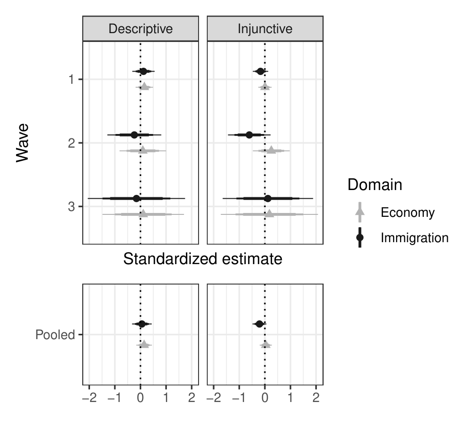

Immigration and redistribution. Same LATE specification.

← Placebos & robustness

## Placebo attitudes

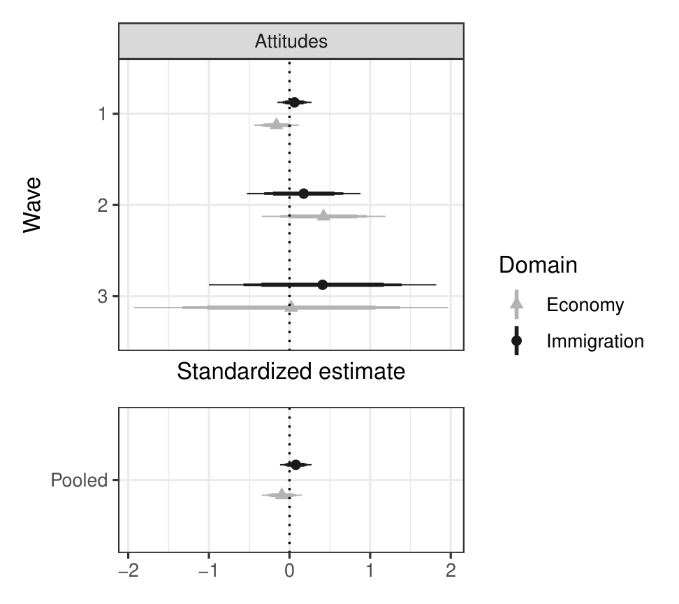

Immigration and economic attitudes.

← Placebos & robustness

## Placebo parties

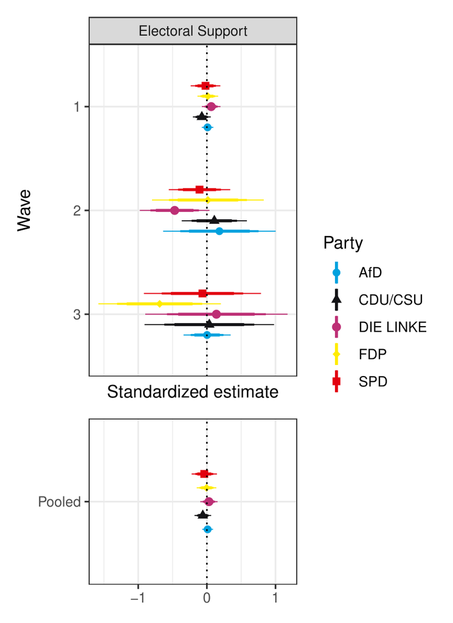

Propensity to vote for parties other than the Greens.

← Placebos & robustness

## Placebo newsletters

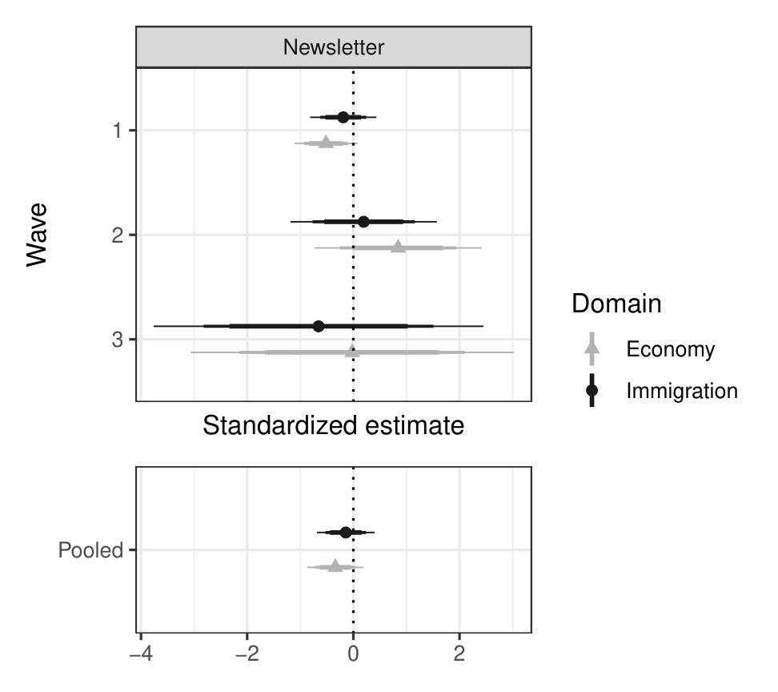

Newsletter sign-up for immigration and redistribution organizations.

← Placebos & robustness

## Placebo donations

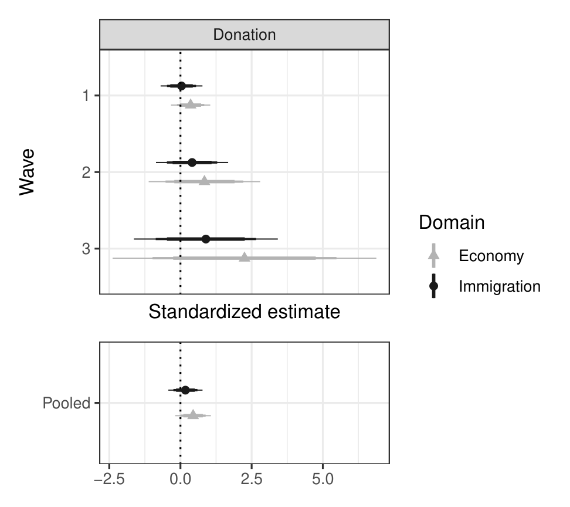

Donations to organizations working on immigration and redistribution.

← Placebos & robustness

## Two-sided tests

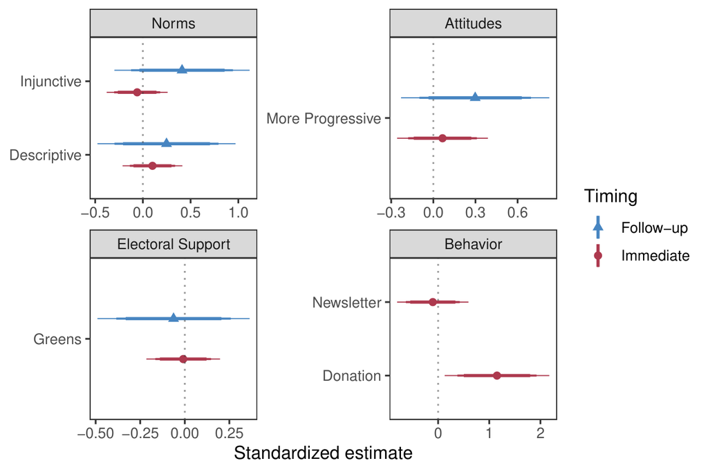

Main outcomes, with two-sided tests. The preregistered tests are one-sided.

← Placebos & robustness

## Covariate-adjusted estimates

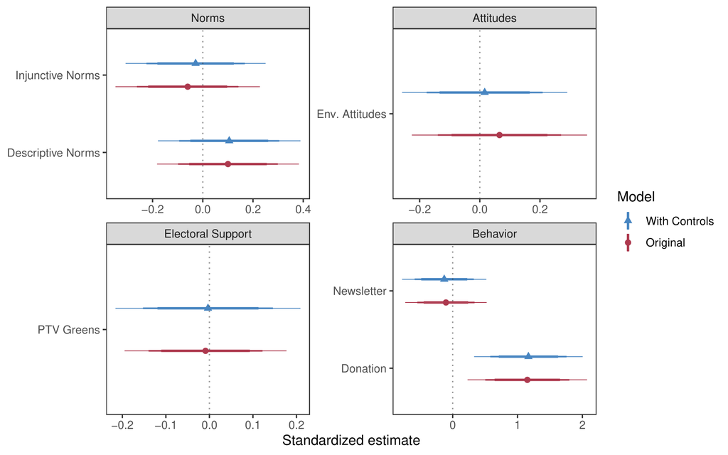

Controls for age and left–right self-placement.

← Placebos & robustness

## Follow-up subset

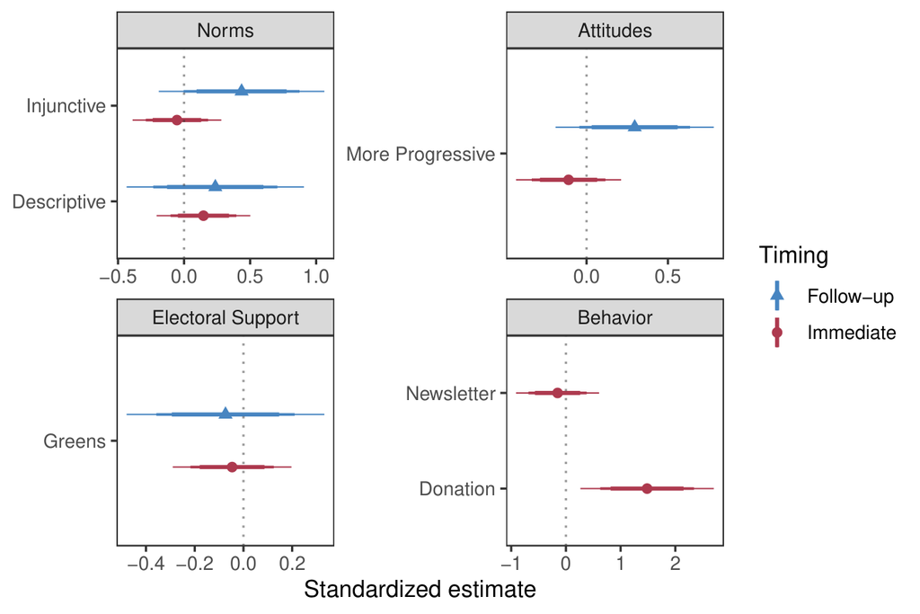

Immediate effects re-estimated on respondents who also completed the follow-up.

← Placebos & robustness

## Random subsamples

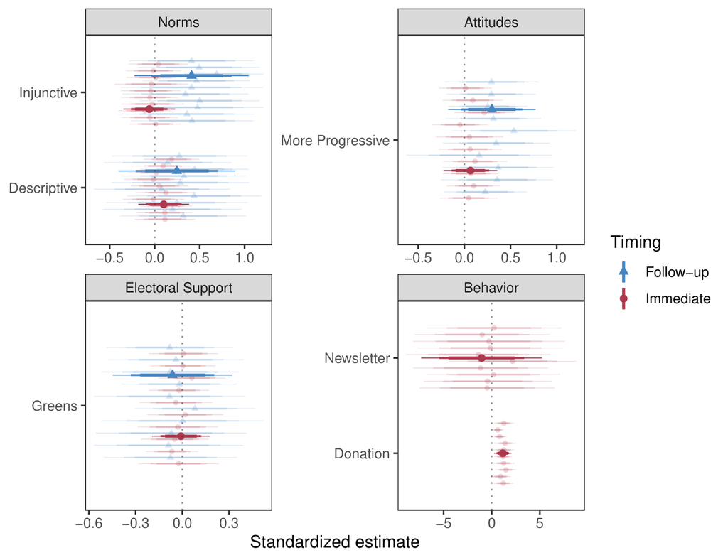

Immediate effects in random subsamples the size of the follow-up.

← Placebos & robustness

## Issue salience

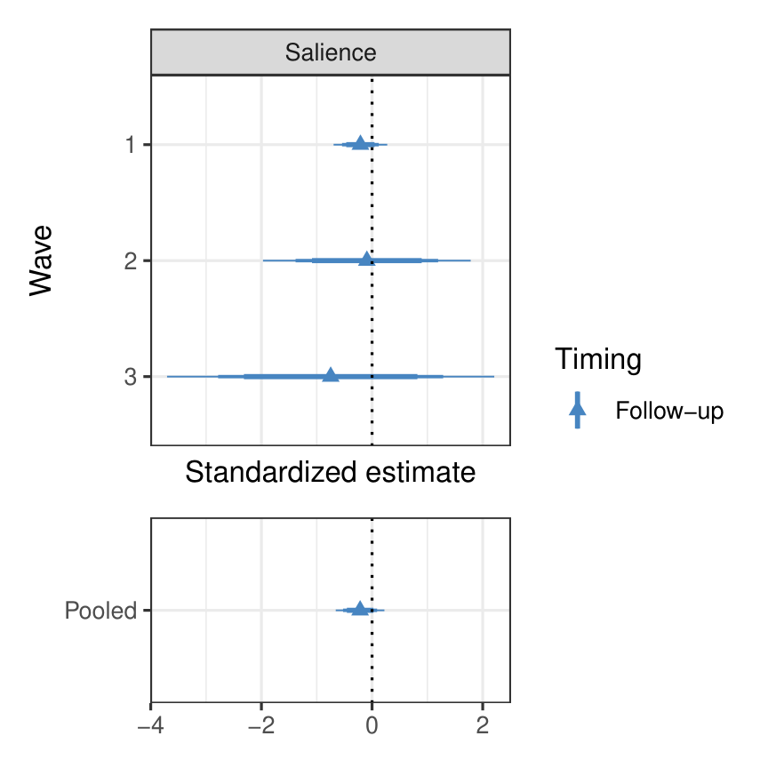

At follow-up, treatment respondents are no more likely to name the environment as the most important problem.

← Placebos & robustness

## Social desirability

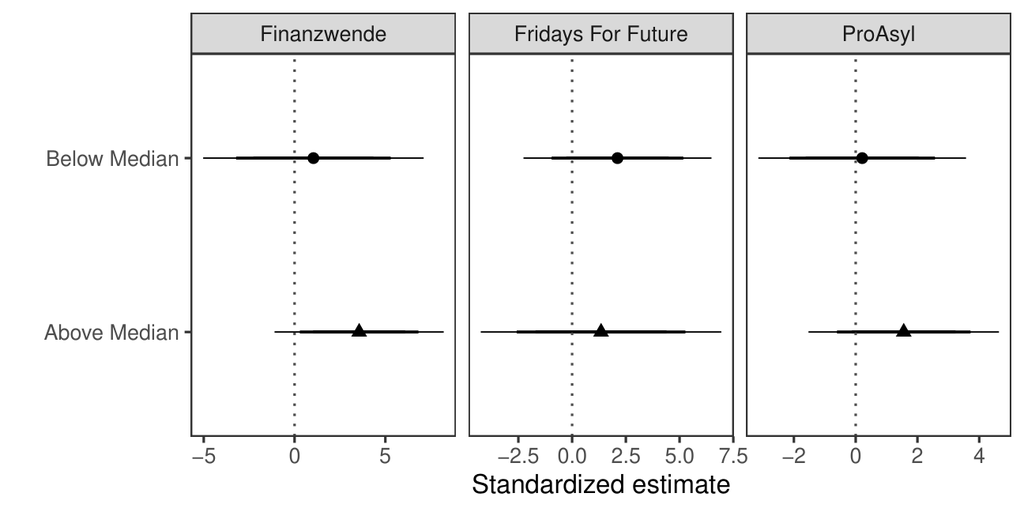

Donation effect by a pre-treatment social-desirability index. Wave 3.

← Placebos & robustness

## Heterogeneity

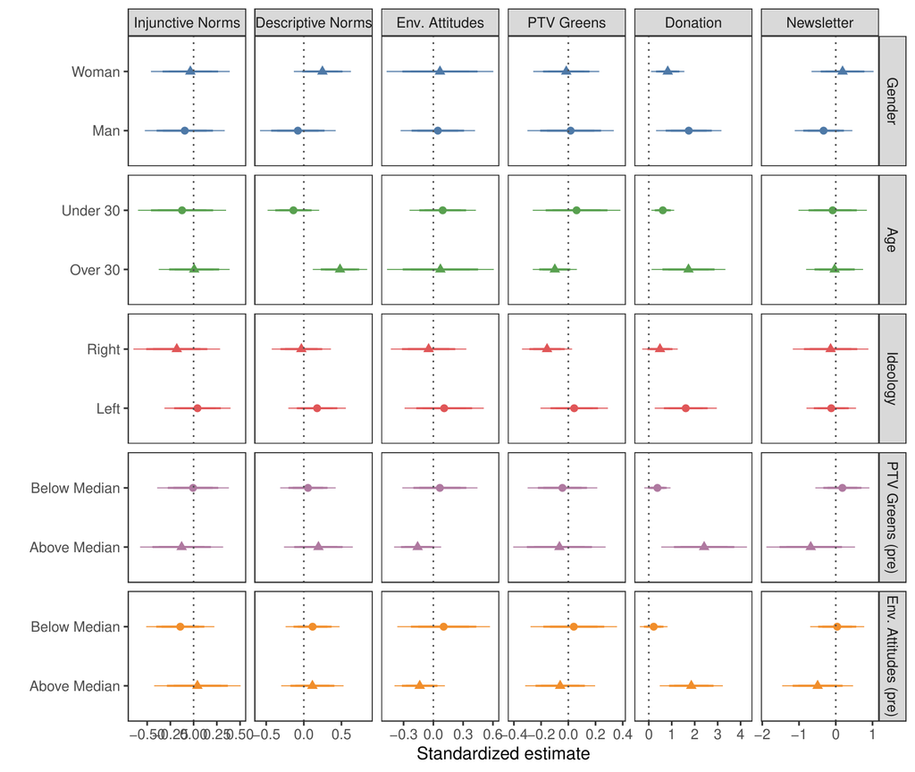

LATE by gender, age, ideology, prior Green support, and prior environmental attitudes.

← Placebos & robustness